# **Introduction:**

[figure not shown]

The number of restaurants in New York is increasing day by day. Lots of students and busy professionals rely on those restaurants due to their hectic lifestyles. Online food delivery service is a great option for them. It provides them with good food from their favorite restaurants. A food aggregator company FoodHub offers access to multiple restaurants through a single smartphone app.

The app allows the restaurants to receive a direct online order from a customer. The app assigns a delivery person from the company to pick up the order after it is confirmed by the restaurant. The delivery person then uses the map to reach the restaurant and waits for the food package. Once the food package is handed over to the delivery person, he/she confirms the pick-up in the app and travels to the customer's location to deliver the food. The delivery person confirms the drop-off in the app after delivering the food package to the customer. The customer can rate the order in the app. The food aggregator earns money by collecting a fixed margin of the delivery order from the restaurants.

The food aggregator company has stored the data of the different orders made by the registered customers in their online portal. They want to analyze the data to get a fair idea about the demand of different restaurants which will help them in enhancing their customer experience. Suppose you are hired as a Data Scientist in this company and the Data Science team has shared some of the key questions that need to be answered. Perform the data analysis to find answers to these questions that will help the company to improve the business.

# **Data overview**

Firstly, we need to understand the key elements of the data we want to explore. Factors such as the data shape, the variable types, the key statistics of the data and the presence or absence of missing values, are prioritary to understand before we do a further analysis of the data in order to get insights.

```python
#Import the necessary libraries.
import pandas as pd
import numpy as np
import matplotlib.pyplot as plt
import seaborn as sns

#Load the dataset.
df=pd.read_csv("foodhub_order.csv")

#Make a copy to save the the original file without changes.
data = df.copy
```

```python
#Check the shape of the graph.
df.shape
```

```
(1898, 9)
```

## **Question 1: How many rows and columns are present in the data?**

The data structure is made by 1898 rows and 9 columns. We should also take a look at the variables in each column.

```python
#Check the overall information of the dataset
df.info()
```

```
<class 'pandas.core.frame.DataFrame'>
RangeIndex: 1898 entries, 0 to 1897
Data columns (total 9 columns):
 #   Column                 Non-Null Count  Dtype
---  ------                 --------------  -----
 0   order_id               1898 non-null   int64
 1   customer_id            1898 non-null   int64
 2   restaurant_name        1898 non-null   object
 3   cuisine_type           1898 non-null   object
 4   cost_of_the_order      1898 non-null   float64
 5   day_of_the_week        1898 non-null   object
 6   rating                 1898 non-null   object
 7   food_preparation_time  1898 non-null   int64
 8   delivery_time          1898 non-null   int64
dtypes: float64(1), int64(4), object(4)
memory usage: 133.6+ KB
```

## **Question 2: What are the datatypes of the different columns in the dataset?**

Here we can see 9 columns with their respective datatype.

The columns "restaurant_name", "cuisine_type", "day_of_the_week", and "rating" are all objects, and therefore, categorical variables while the other ones are numerical in nature.

The numerical columns are 4 integer variables("order_id","customer_id","food_preparation_time" and "delivery_time") and 1 floating variaable("cost_of_the_order")

```python
#Check the first five observations from the data
df.head()
```

|  | order_id | customer_id | restaurant_name | cuisine_type | cost_of_the_order | day_of_the_week | rating | food_preparation_time | delivery_time |
| --- | --- | --- | --- | --- | --- | --- | --- | --- | --- |
| 0 | 1477147 | 337525 | Hangawi | Korean | 30.75 | Weekend | Not given | 25 | 20 |
| 1 | 1477685 | 358141 | Blue Ribbon Sushi Izakaya | Japanese | 12.08 | Weekend | Not given | 25 | 23 |
| 2 | 1477070 | 66393 | Cafe Habana | Mexican | 12.23 | Weekday | 5 | 23 | 28 |
| 3 | 1477334 | 106968 | Blue Ribbon Fried Chicken | American | 29.20 | Weekend | 3 | 25 | 15 |
| 4 | 1478249 | 76942 | Dirty Bird to Go | American | 11.59 | Weekday | 4 | 25 | 24 |

```python
# Referencing the variables as dataframes.
df.order_id = df["order_id"]
df.customer_id=df["customer_id"]
df.restaurant_name = df['restaurant_name']
df.cuisine_type = df['cuisine_type']
df.cost_of_the_order = df['cost_of_the_order']
df.day_of_the_week = df['day_of_the_week']
df.rating = df['rating']
df.food_preparation_time = df['food_preparation_time']
df.delivery_time = df["delivery_time"]
```

#### *Variables*

**restaurant_name**: Name of the restaurant

**cuisine_type**: Typw of cuisine ordered by the customer

**cost**: Cost of the order

**day_of_the_week**: Indicates whether the order is placed on a weekday or weekend (Weekday being from Monday to Friday, and weekend from Saturday to Sunday)

**rating**: Rating given by the customer out of 5.

**food_preparation_time**: Time (in minutes) taken by the restaurant to prepare the food. This is calculated by taking the difference between the timestamps of the restaurant's order confirmation and the delivery person's pick-up confirmation.

**delivery_time**: Time (in minutes) taken by the delivery person to deliver the food package. This is calculated by taking the difference between the timestamps of the delivery person's pick-up confirmation and drop-off information

```python
#Check the last five observations from the data
df.tail()
```

|  | order_id | customer_id | restaurant_name | cuisine_type | cost_of_the_order | day_of_the_week | rating | food_preparation_time | delivery_time |
| --- | --- | --- | --- | --- | --- | --- | --- | --- | --- |
| 1893 | 1476701 | 292602 | Chipotle Mexican Grill $1.99 Delivery | Mexican | 22.31 | Weekend | 5 | 31 | 17 |
| 1894 | 1477421 | 397537 | The Smile | American | 12.18 | Weekend | 5 | 31 | 19 |
| 1895 | 1477819 | 35309 | Blue Ribbon Sushi | Japanese | 25.22 | Weekday | Not given | 31 | 24 |
| 1896 | 1477513 | 64151 | Jack's Wife Freda | Mediterranean | 12.18 | Weekday | 5 | 23 | 31 |
| 1897 | 1478056 | 120353 | Blue Ribbon Sushi | Japanese | 19.45 | Weekend | Not given | 28 | 24 |

## **Question 3: Are there any missing values in the data? If yes, treat them using an appropriate method.**

If we check for missing values in the csv file, we will see there are no missing values. That means our data is ready for further analysis.

```python
df.isnull().sum()
```

```
order_id                 0
customer_id              0
restaurant_name          0
cuisine_type             0
cost_of_the_order        0
day_of_the_week          0
rating                   0
food_preparation_time    0
delivery_time            0
dtype: int64
```

## **Question 4: Check the statistical summary of the data. What is the minimum, average, and maximum time it takes for food to be prepared once an order is placed?**

```python
#Summarize the key statistics from the data.
df.describe(include="all").T
```

|  | count | unique | top | freq | mean | std | min | 25% | 50% | 75% | max |
| --- | --- | --- | --- | --- | --- | --- | --- | --- | --- | --- | --- |
| order_id | 1898.0 | NaN | NaN | NaN | 1477495.5 | 548.049724 | 1476547.0 | 1477021.25 | 1477495.5 | 1477969.75 | 1478444.0 |
| customer_id | 1898.0 | NaN | NaN | NaN | 171168.478398 | 113698.139743 | 1311.0 | 77787.75 | 128600.0 | 270525.0 | 405334.0 |
| restaurant_name | 1898 | 178 | Shake Shack | 219 | NaN | NaN | NaN | NaN | NaN | NaN | NaN |
| cuisine_type | 1898 | 14 | American | 584 | NaN | NaN | NaN | NaN | NaN | NaN | NaN |
| cost_of_the_order | 1898.0 | NaN | NaN | NaN | 16.498851 | 7.483812 | 4.47 | 12.08 | 14.14 | 22.2975 | 35.41 |
| day_of_the_week | 1898 | 2 | Weekend | 1351 | NaN | NaN | NaN | NaN | NaN | NaN | NaN |
| rating | 1898 | 4 | Not given | 736 | NaN | NaN | NaN | NaN | NaN | NaN | NaN |
| food_preparation_time | 1898.0 | NaN | NaN | NaN | 27.37197 | 4.632481 | 20.0 | 23.0 | 27.0 | 31.0 | 35.0 |
| delivery_time | 1898.0 | NaN | NaN | NaN | 24.161749 | 4.972637 | 15.0 | 20.0 | 25.0 | 28.0 | 33.0 |

*Key statistical insights*

## **Question 5: How many orders are not rated?**

If we look back to the the statistical description of the variables we can see that the most repeated value of the variable "rating", is "Not given" with a frequency of 736 times.

```python
#Summarize the key statistics from the data.
df["rating"].value_counts()
```

```
Not given    736
5            588
4            386
3            188
Name: rating, dtype: int64
```

Now all of our values are clean and we are ready to do our exploratory data analysis.

# **Exploratory Data Analysis**

## Univariate analysis

Question 6: Explore all the variables and provide observations on their distributions. (Generally, histograms, boxplots, countplots, etc. are used for univariate exploration.)

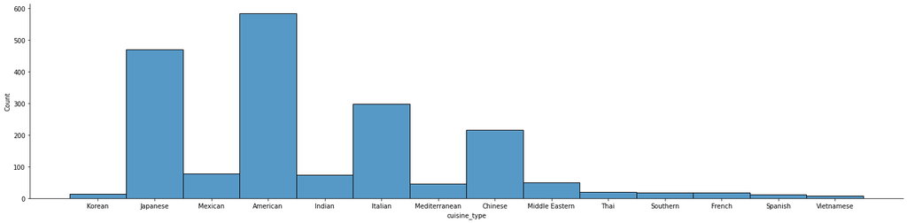

```python
sns.displot(data=df,x="cuisine_type",kind="hist",height=5,aspect=4)
```

### **Question 7**: Which are the top 5 restaurants in terms of the number of orders received? [1 mark]

The five top restaurants in terms of number of orders received are Shake Shack, The Meatball Soup, Blue Ribbon Sushi, Parm and Redfarm Hudson.

```python
sns.displot(data=df,x="restaurant_name",kind="hist",aspect=70)
```

[figure not shown]

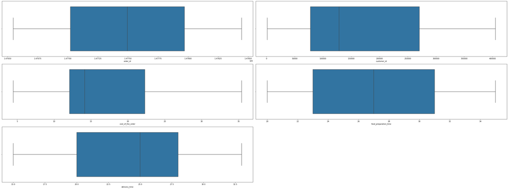

```python
cols = 2
rows = 3
num_cols = df.select_dtypes(exclude="object").columns

fig = plt.figure( figsize=(cols*20, rows*5))
for i, col in enumerate(num_cols):

    ax=fig.add_subplot(rows,cols,i+1)

    sns.boxplot(x = df[col], ax = ax)

fig.tight_layout()
plt.show()
```

Looking at the boxplots we can see that the most important variables are the cost of the order, the food preparation time and the delivery time. Some facts about each variable are the following

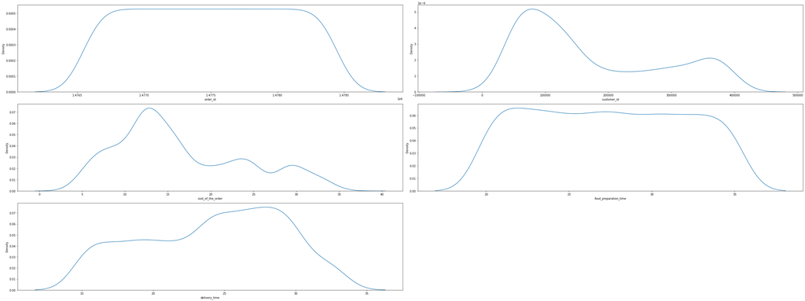

```python
fig = plt.figure( figsize=(cols*20, rows*5))
for i, col in enumerate(num_cols):

    ax=fig.add_subplot(rows,cols,i+1)

    sns.kdeplot(x = df[col], ax = ax)

fig.tight_layout()
plt.show()
```

### **Question 8**: Which is the most popular cuisine on weekends? [1 mark]

The most preferred cuisine type during weekends is also American with a frequency of 415 times.

```python
d =df[df["day_of_the_week"]=="Weekend"]
d.groupby("cuisine_type").describe()
```

| cuisine_type | order_id count | order_id mean | order_id std | order_id min | order_id 25% | order_id 50% | order_id 75% | order_id max | customer_id count | customer_id mean | ... | food_preparation_time 75% | food_preparation_time max | delivery_time count | delivery_time mean | delivery_time std | delivery_time min | delivery_time 25% | delivery_time 50% | delivery_time 75% | delivery_time max |
| --- | --- | --- | --- | --- | --- | --- | --- | --- | --- | --- | --- | --- | --- | --- | --- | --- | --- | --- | --- | --- | --- |
| American | 415.0 | 1.477490e+06 | 557.752550 | 1476547.0 | 1477001.50 | 1477476.0 | 1477988.50 | 1478444.0 | 415.0 | 182716.710843 | ... | 31.00 | 35.0 | 415.0 | 22.542169 | 4.486429 | 15.0 | 19.00 | 23.0 | 26.00 | 30.0 |
| Chinese | 163.0 | 1.477521e+06 | 537.181218 | 1476588.0 | 1477043.00 | 1477522.0 | 1477937.00 | 1478441.0 | 163.0 | 177580.613497 | ... | 31.50 | 35.0 | 163.0 | 22.269939 | 4.395651 | 15.0 | 19.00 | 22.0 | 26.00 | 30.0 |
| French | 13.0 | 1.477428e+06 | 575.042406 | 1476754.0 | 1476922.00 | 1477549.0 | 1477704.00 | 1478349.0 | 13.0 | 163750.615385 | ... | 31.00 | 35.0 | 13.0 | 24.615385 | 4.073051 | 17.0 | 22.00 | 24.0 | 29.00 | 29.0 |
| Indian | 49.0 | 1.477627e+06 | 591.232670 | 1476549.0 | 1477185.00 | 1477776.0 | 1478079.00 | 1478436.0 | 49.0 | 163525.306122 | ... | 31.00 | 35.0 | 49.0 | 22.346939 | 5.023076 | 15.0 | 18.00 | 21.0 | 26.00 | 30.0 |
| Italian | 207.0 | 1.477560e+06 | 557.498490 | 1476553.0 | 1477063.50 | 1477636.0 | 1478009.50 | 1478423.0 | 207.0 | 153483.043478 | ... | 31.00 | 35.0 | 207.0 | 22.705314 | 4.861691 | 15.0 | 19.00 | 23.0 | 27.00 | 30.0 |
| Japanese | 335.0 | 1.477459e+06 | 555.605723 | 1476548.0 | 1476983.00 | 1477456.0 | 1477939.00 | 1478440.0 | 335.0 | 159809.032836 | ... | 32.00 | 35.0 | 335.0 | 22.519403 | 4.754331 | 15.0 | 18.00 | 23.0 | 27.00 | 30.0 |
| Korean | 11.0 | 1.477481e+06 | 529.141466 | 1476856.0 | 1477036.50 | 1477307.0 | 1477865.50 | 1478363.0 | 11.0 | 233061.363636 | ... | 27.50 | 33.0 | 11.0 | 20.000000 | 3.660601 | 16.0 | 16.50 | 20.0 | 21.50 | 26.0 |
| Mediterranean | 32.0 | 1.477445e+06 | 523.708042 | 1476562.0 | 1477007.75 | 1477432.0 | 1477810.25 | 1478387.0 | 32.0 | 127002.468750 | ... | 33.00 | 35.0 | 32.0 | 21.312500 | 4.553889 | 15.0 | 17.75 | 21.0 | 24.25 | 29.0 |
| Mexican | 53.0 | 1.477475e+06 | 558.009049 | 1476613.0 | 1477051.00 | 1477425.0 | 1478008.00 | 1478437.0 | 53.0 | 193035.735849 | ... | 31.00 | 35.0 | 53.0 | 22.641509 | 4.067197 | 16.0 | 19.00 | 22.0 | 26.00 | 30.0 |
| Middle Eastern | 32.0 | 1.477459e+06 | 621.938216 | 1476556.0 | 1476814.75 | 1477479.5 | 1477970.00 | 1478443.0 | 32.0 | 184777.343750 | ... | 29.25 | 33.0 | 32.0 | 21.750000 | 5.285403 | 15.0 | 17.00 | 21.0 | 27.00 | 30.0 |
| Southern | 11.0 | 1.477488e+06 | 552.910925 | 1476657.0 | 1477091.00 | 1477538.0 | 1477772.00 | 1478384.0 | 11.0 | 133339.636364 | ... | 33.00 | 35.0 | 11.0 | 20.727273 | 4.713617 | 15.0 | 16.00 | 21.0 | 24.50 | 28.0 |
| Spanish | 11.0 | 1.477540e+06 | 490.943229 | 1476739.0 | 1477377.00 | 1477454.0 | 1477888.50 | 1478375.0 | 11.0 | 187701.272727 | ... | 28.00 | 35.0 | 11.0 | 23.000000 | 4.816638 | 17.0 | 19.50 | 22.0 | 26.50 | 30.0 |
| Thai | 15.0 | 1.477671e+06 | 435.268204 | 1476902.0 | 1477391.00 | 1477699.0 | 1477894.00 | 1478391.0 | 15.0 | 189736.066667 | ... | 34.00 | 35.0 | 15.0 | 22.266667 | 5.006662 | 15.0 | 17.50 | 24.0 | 26.50 | 29.0 |
| Vietnamese | 4.0 | 1.477179e+06 | 269.558126 | 1476957.0 | 1476999.75 | 1477101.5 | 1477280.50 | 1477555.0 | 4.0 | 217569.250000 | ... | 31.50 | 33.0 | 4.0 | 25.000000 | 4.242641 | 19.0 | 24.25 | 26.0 | 26.75 | 29.0 |

14 rows × 40 columns

### **Question 9**: What percentage of the orders cost more than 20 dollars? [2 marks]

The number of orders above $ 20 USD makes 29.24 % of the whole orders.

```python
df[df["cost_of_the_order"]>20].count()
```

```
order_id                 555
customer_id              555
restaurant_name          555
cuisine_type             555
cost_of_the_order        555
day_of_the_week          555
rating                   555
food_preparation_time    555
delivery_time            555
dtype: int64
```

```python
x = 555/1898*100
x
```

```
29.24130663856691
```

### **Question 10**: What is the mean order delivery time? [1 mark]

The mean order delivery time is about 24.161749 minutes.

```python
df.delivery_time.mean()
```

```
24.161749209694417
```

**Question 11: The company has decided to give 20% discount vouchers to the top 5 most frequent customers. Find the IDs of these customers and the number of orders they placed.** [1 mark] In [ ]:

The top customers in terms of orders are: 52832 13 orders 47440 10 orders 83287 9 orders 250494 8 orders 259341 7 orders

They can receive a 20% discount voucher.

```python
df.customer_id.value_counts().head()
```

```
52832     13
47440     10
83287      9
250494     8
259341     7
Name: customer_id, dtype: int64
```

### **Multivariate analysis**

Question 12: Perform a multivariate analysis to explore relationships between the important variables in the dataset. (It is a good idea to explore relations between numerical variables as well as relations between numerical and categorical variables) [10 marks]

As we can see both in the heatmap and the correlation table, there are no strong correlations between the numerical variables.

```python
df.corr()
```

|  | order_id | customer_id | cost_of_the_order | food_preparation_time | delivery_time |
| --- | --- | --- | --- | --- | --- |
| order_id | 1.000000 | -0.013960 | 0.021171 | -0.007026 | 0.009690 |
| customer_id | -0.013960 | 1.000000 | -0.001322 | -0.030330 | -0.009885 |
| cost_of_the_order | 0.021171 | -0.001322 | 1.000000 | 0.041527 | -0.029949 |
| food_preparation_time | -0.007026 | -0.030330 | 0.041527 | 1.000000 | 0.011094 |
| delivery_time | 0.009690 | -0.009885 | -0.029949 | 0.011094 | 1.000000 |

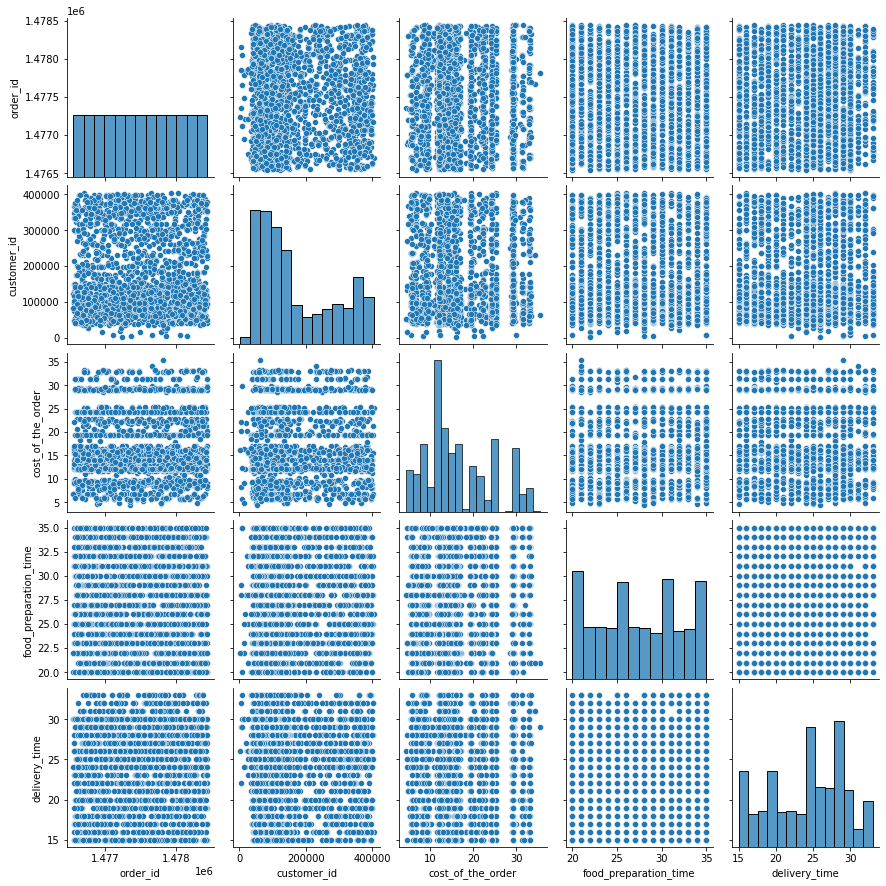

```python
sns.pairplot(df)
```

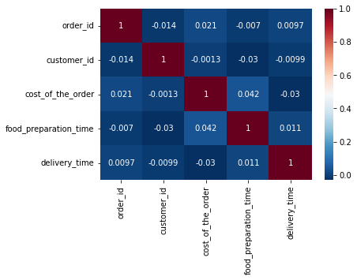

```python
sns.heatmap(df.corr(),cmap='RdBu_r',
    annot=True)
```

```python
df.groupby('cuisine_type')['cost_of_the_order'].describe()
```

| cuisine_type | count | mean | std | min | 25% | 50% | 75% | max |
| --- | --- | --- | --- | --- | --- | --- | --- | --- |
| American | 584.0 | 16.319829 | 7.462290 | 4.71 | 12.0800 | 14.120 | 22.2600 | 33.18 |
| Chinese | 215.0 | 16.305209 | 7.631503 | 4.75 | 12.1050 | 14.120 | 21.8800 | 34.19 |
| French | 18.0 | 19.793889 | 6.508990 | 11.98 | 13.0525 | 20.470 | 23.6550 | 29.25 |
| Indian | 73.0 | 16.919726 | 7.897493 | 5.34 | 11.6400 | 16.150 | 24.2000 | 33.03 |
| Italian | 298.0 | 16.418691 | 7.268831 | 5.05 | 12.0800 | 14.480 | 22.2600 | 33.03 |
| Japanese | 470.0 | 16.304532 | 7.422722 | 4.47 | 12.0800 | 14.070 | 21.8300 | 33.37 |
| Korean | 13.0 | 14.001538 | 7.563540 | 5.77 | 11.8400 | 12.180 | 14.0200 | 30.75 |
| Mediterranean | 46.0 | 15.474783 | 7.604720 | 5.67 | 12.0925 | 13.995 | 18.7825 | 35.41 |
| Mexican | 77.0 | 16.933117 | 7.555108 | 4.85 | 12.0800 | 15.570 | 22.3600 | 33.32 |
| Middle Eastern | 49.0 | 18.820612 | 8.086499 | 5.77 | 12.9500 | 16.300 | 25.2700 | 32.93 |
| Southern | 17.0 | 19.300588 | 7.966032 | 7.38 | 12.4700 | 16.110 | 29.1500 | 31.43 |
| Spanish | 12.0 | 18.994167 | 6.658207 | 12.13 | 12.9150 | 16.520 | 24.4925 | 29.10 |
| Thai | 19.0 | 19.207895 | 7.579149 | 6.69 | 12.7100 | 19.350 | 24.2000 | 32.93 |
| Vietnamese | 7.0 | 12.882857 | 5.319623 | 6.01 | 10.0200 | 12.130 | 14.8700 | 22.26 |

```python
df.groupby('cuisine_type')['rating'].describe()
```

| cuisine_type | count | unique | top | freq |
| --- | --- | --- | --- | --- |
| American | 584 | 4 | Not given | 216 |
| Chinese | 215 | 4 | Not given | 82 |
| French | 18 | 4 | Not given | 8 |
| Indian | 73 | 4 | 5 | 32 |
| Italian | 298 | 4 | Not given | 126 |
| Japanese | 470 | 4 | Not given | 197 |
| Korean | 13 | 4 | Not given | 4 |
| Mediterranean | 46 | 4 | 5 | 16 |
| Mexican | 77 | 4 | Not given | 29 |
| Middle Eastern | 49 | 4 | 4 | 16 |
| Southern | 17 | 4 | 4 | 7 |
| Spanish | 12 | 3 | Not given | 6 |
| Thai | 19 | 3 | Not given | 10 |
| Vietnamese | 7 | 4 | 5 | 2 |

The cuisine types with the highest rating time are Indian and Mediterranean, however; the ones with the most ratings overall are American, Italian and Japanese.

### **Question 13:** The company wants to provide a promotional offer in the advertisement of the restaurants. The condition to get the offer is that the restaurants must have a rating count of more than 50 and the average rating should be greater than 4. Find the restaurants fulfilling the criteria to get the promotional offer. [3 marks]

```python
from numpy.lib.function_base import quantile
quantile
```

```
<function numpy.quantile>
```

```python
df.groupby('restaurant_name')['rating'].describe().value_counts()>50
```

```
count  unique  top        freq
1      1       5          1       False
               Not given  1       False
               4          1       False
3      2       5          2       False
1      1       3          1       False
                                  ...
12     4       Not given  4       False
13     3       Not given  7       False
       4       5          5       False
14     4       5          5       False
219    4       Not given  86      False
Length: 85, dtype: bool
```

### **Question 14:** The company charges the restaurant 25% on the orders having cost greater than 20 dollars and 15% on the orders having cost greater than 5 dollars. Find the net revenue generated by the company across all orders. [3 marks]

```python
df[df["cost_of_the_order"]>20].sum()
```

```
order_id                                                         820026389
customer_id                                                       94823444
restaurant_name          HangawiBlue Ribbon Fried ChickenTamarind TriBe...
cuisine_type             KoreanAmericanIndianAmericanJapaneseAmericanAm...
cost_of_the_order                                                 14754.91
day_of_the_week          WeekendWeekendWeekdayWeekendWeekendWeekendWeek...
rating                   Not given335Not given455555545Not given555Not ...
food_preparation_time                                                15298
delivery_time                                                        13326
dtype: object
```

```python
df[df["cost_of_the_order"]>5].sum()
```

```
order_id                                                        2790988675
customer_id                                                      323472074
restaurant_name          HangawiBlue Ribbon Sushi IzakayaCafe HabanaBlu...
cuisine_type             KoreanJapaneseMexicanAmericanAmericanIndianIta...
cost_of_the_order                                                 31272.08
day_of_the_week          WeekendWeekendWeekdayWeekendWeekdayWeekdayWeek...
rating                   Not givenNot given5343Not given355Not given553...
food_preparation_time                                                51710
delivery_time                                                        45641
dtype: object
```

```python
#Total cost of orders above 20 USD
A20 = 14754.91
A20
#Total cost of orders above 5 and below 20 USD
A5B20 = 31272.08-14754.91
A5B20
```

```
16517.170000000002
```

```python
#New cost of orders above 20 Dollars
Revenue1 = A20*1.25
Revenue2 = A5B20*1.05
TotalRevenue = Revenue1+Revenue2
NetRevenue = TotalRevenue-A20-A5B20
NetRevenue
```

```
4514.586000000003
```

### **Question 15:** The company wants to analyze the total time required to deliver the food. What percentage of orders take more than 60 minutes to get delivered from the time the order is placed? (The food has to be prepared and then delivered.) [2 marks]

The percentage of orders with above 60 minutes of total delivery time is 12.90%.

```python
ft=df.delivery_time+df.food_preparation_time
tft=ft<60
tft.describe()
```

```
count     1898
unique       2
top       True
freq      1653
dtype: object
```

```python
#Total orders above 60 minutes of total delivery time
Orders = 1898-1653

#Percentage of orders above 60 minutes of total delivery time
Percentage = Orders/1898*100
Percentage
```

```
12.908324552160169
```

### **Question 16:** The company wants to analyze the delivery time of the orders on weekdays and weekends. How does the mean delivery time vary during weekdays and weekends? [2 marks]

The delivery time is smaller in weekends than in weekdays by almost 6 minutes.

```python
df.groupby('day_of_the_week')['delivery_time'].mean()
```

```
day_of_the_week
Weekday    28.340037
Weekend    22.470022
Name: delivery_time, dtype: float64
```

### **Question 17:** What are your conclusions from the analysis? What recommendations would you like to share to help improve the business? (You can use cuisine type and feedback ratings to drive your business recommendations.)

### **Conclusions**

In summary, the most preferred food type overall is American, followed by Japanese, Italian and Chinese. There is really a lack of strong correlation between numerical variables, but that doesn't mean there are no insights within the data. For instance, we can see that the most preferred restaurants coincide with the food types that are most liked by the public. That is the case of Shake Shack, Blue Ribbon Sushi The Meatball Soup, Parm and Redfarm Hudson.

There were some problem regarding the insights from data like the fact that there were many reviews with no ratings. That is a limitation from implementing further analysis regarding the most liked cuisine types.

Overall, some recommendations I would make for the company are: